# Los coches del jefe

Hugo César Octavio del Sueldo

11/21/2020

## Introduccion

El archivo data.sav contiene información acerca de 125 vehículos de todo terreno clásicos. Tan clásicos, que sus precios vienen expresados en pesetas, que era la moneda oficial del Reino de España antes de la entrada en vigor del euro. En su afán como coleccionista, el dueño del family office en el que ud. trabaja los ha comprado todos y ha recogido, además, información relevante de ellos, expresada en las variables de las que tiene información en este documento.

El dueño del family office, al que ud. reporta, quiere dividir los todo-terreno en las distintas propiedades que tiene. Dado que cuenta con hasta 10 lugares en los que podría conservar los vehículos, su trabajo consiste en asignar de la forma más eficiente y consistente los distintos vehículos, agrupándolos en virtud de las características que ud. considere oportunas. Debe por tanto informarse acerca de qué características pueden ser relevantes y cuáles no para el trabajo a realizar. Ser la persona de confianza del dueño tiene esas cosas, a veces no hay más remedio que entrar a estudiar cosas para las que ud. no se ha formado.

Una vez conocidas y justificadas cuáles son las características sobre las que va a trabajar, deberá explorar a qué datos se enfrenta, siempre con la mente puesta en la segmentación que deberá llevar a cabo más adelante.

Así pues, prepare un informe de 5 páginas justificando qué características ha considerado relevantes, por qué ha rechazado, si acaso, algunas otras (esto le llevará no más de una página) y describa, asimismo, en un máximo de 4 páginas adicionales y sin perder la perspectiva de la segmentación que más adelante llevará a cabo, las características de los vehículos que su jefe ha comprado.

### Diccionario de variables

- `Marca :` Marca del Vehículo.
- `Modelo :` Modelo del Vehículo.
- `PVP :` El precio de Venta del Vehículo (en pesetas).
- `Cilindro :` Número de cilindros.
- `CC :` Cilindrada del Vehículo (en cm. cúbicos).
- `Potencia :` Potencia (CV).
- `RPM :` Revoluciones por minuto.
- `Peso :` Peso del vehículo.
- `Plazas :` Número de asientos que tiene el vehículo.
- `Cons90 :` Consumo de combustible cuando tiene velocidad de 90 Km/h.
- `Cons120 :` Consumo de combustible cuando tiene velocidad de 120 Km/h.
- `ConsUrb :` Consumo de combustible cuando transita en zona urbana.
- `Velocida :` Velocidad máxima.
- `Acelerac :` Aceleración de 0 a 100.
- `Acel2 :` Tiempo de aceleración.

El criterio que voy a utilizar sera completar los datos faltantes de cada una de las variables con el promedio de aquellos vehiculos de la misma marca o modelo. Asi voy a ir revisando el fichero fila a fila observando a que dato corresponde el Na faltante asignandole un valor en base a esta regla de decision. He tomado esta decision ya que si descartaria los valores Na directamente estaria perdiendo muchisima informacion. Por otro lado, aquellos variables que no tengan valores de referencia de otros vehiculos para usarlos en las imputaciones faltantes, lo que se hizo fue reemplazarlos por la media global de las observaciones.

Ya completados los datos del dataframe, procedemos a analizar en detalle cada una de las variables con el fin de filtrar aquellas variables que consideramos relevantes para el analisis dejando afuera algunas que no consideramos oportundas.

Procederemos primero a escalar las variables numericas para poder compararlas

A traves de la funcion scale, escalamos los valores numericos para que esten en la misma escala metrica para que podamos realizar el analisis

# graficos de las variables de los vehiculos

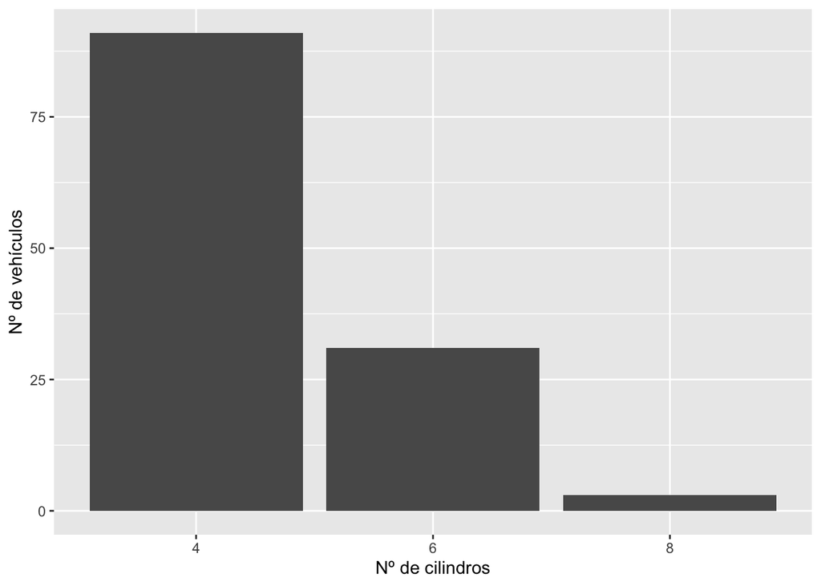

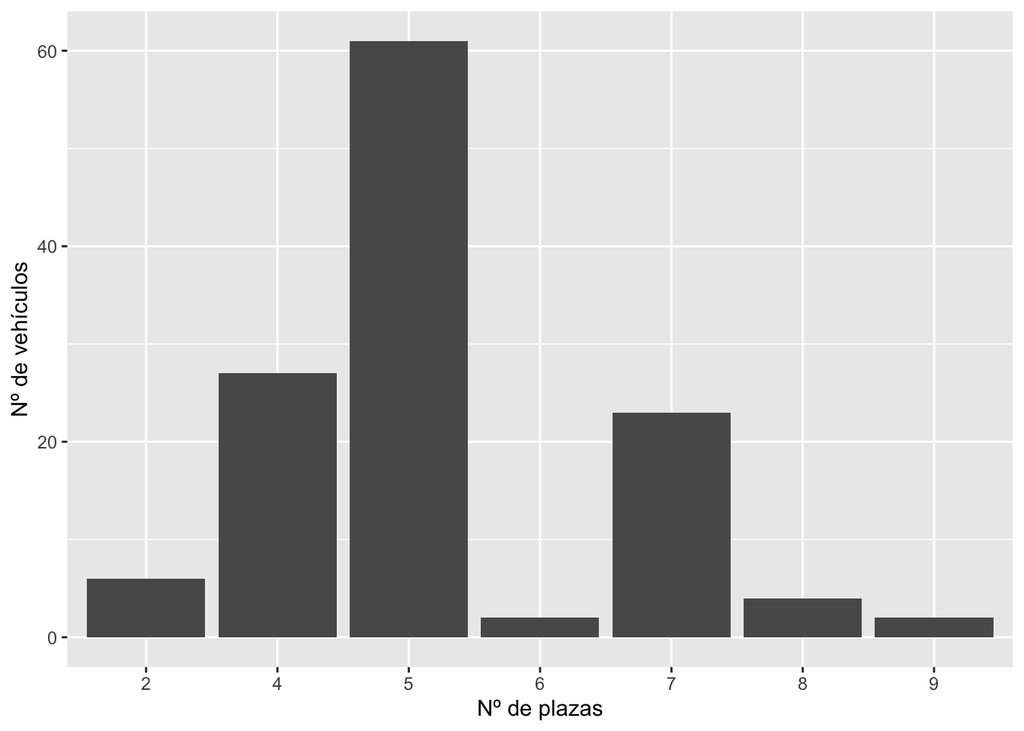

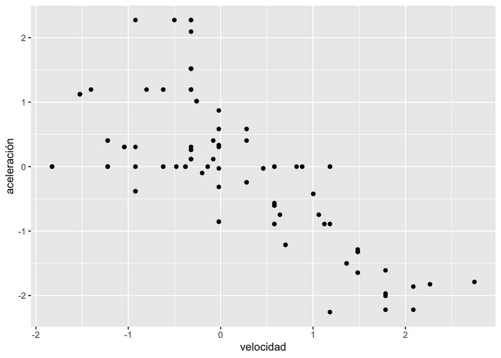

Aqui podemos apreciar como a mayor velocidad, menor es la aceleracion que se genera por lo vehiculos.

En una aproximación naive, se podría suponer que los consumos han de estar relacionados con el peso y, este a su vez con el número de plazas del vehículo; lo cual podría conducir a prescindir del peso o del número de plazas. A continuación, se exponen en los siguientes gráficos, la relación entre las tres variables mencionadas.

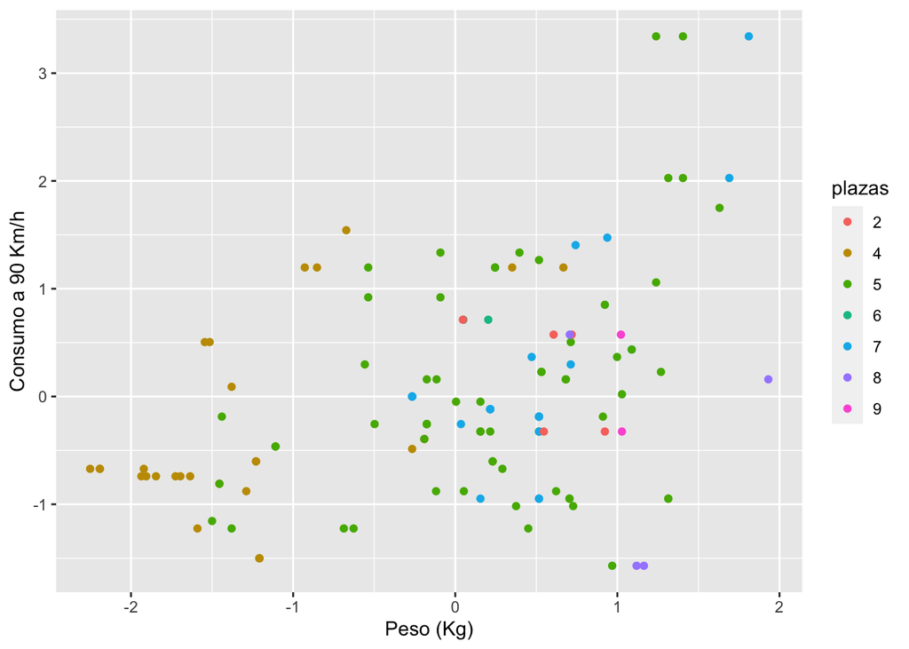

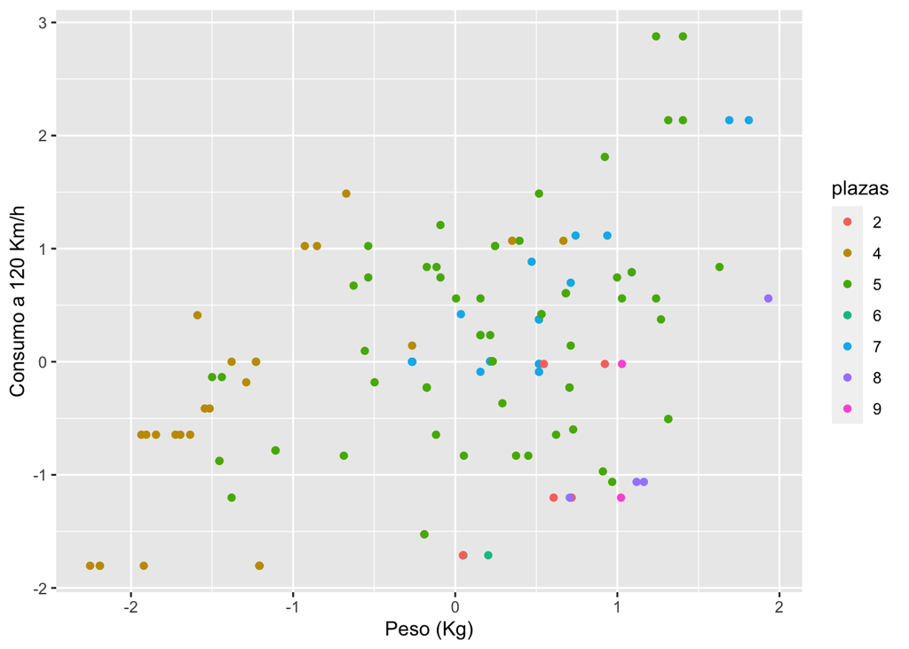

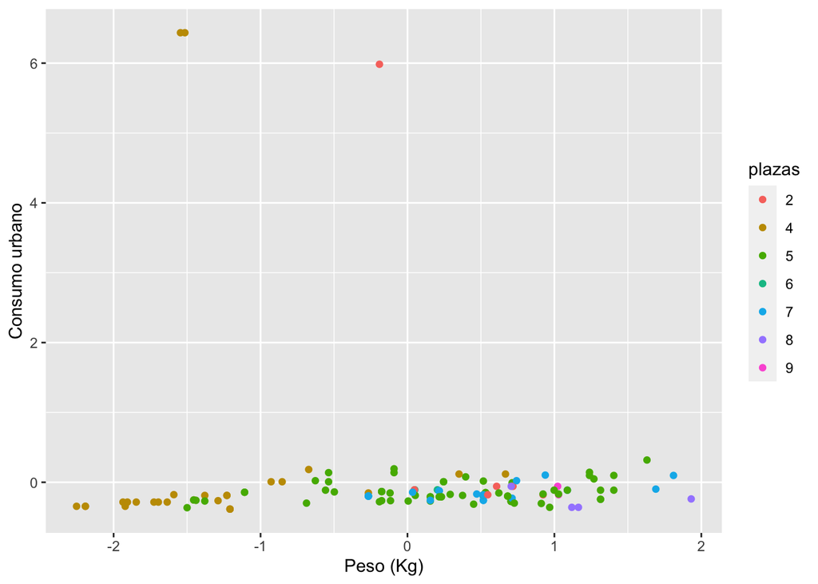

En los diagramas de dispersión se aprecia la relación existente entre las variables, por norma general, a mayor peso, mayor consumo. Sin embargo, la relación existente entre el peso y el número de plazas no queda del todo bien definida. En la siguiente ilustración se observa mejor.

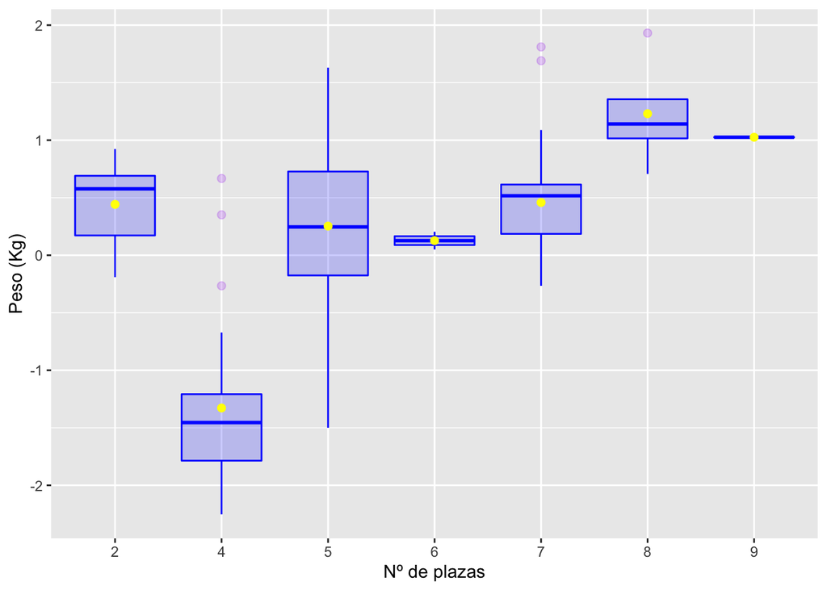

En el diagrama de cajas se observa que aquellos vehículos de 2 plazas, pese a que el sentido común nos haga pensar que tienen que pesar menos que aquellos con un mayor número de plazas, pesan más en muchas ocasiones que el resto de los vehículos. Por tanto, se conservan ambas variables en esta primera etapa.

#Respecto a las variables numéricas de motor se calcula la matriz de correlaciones:

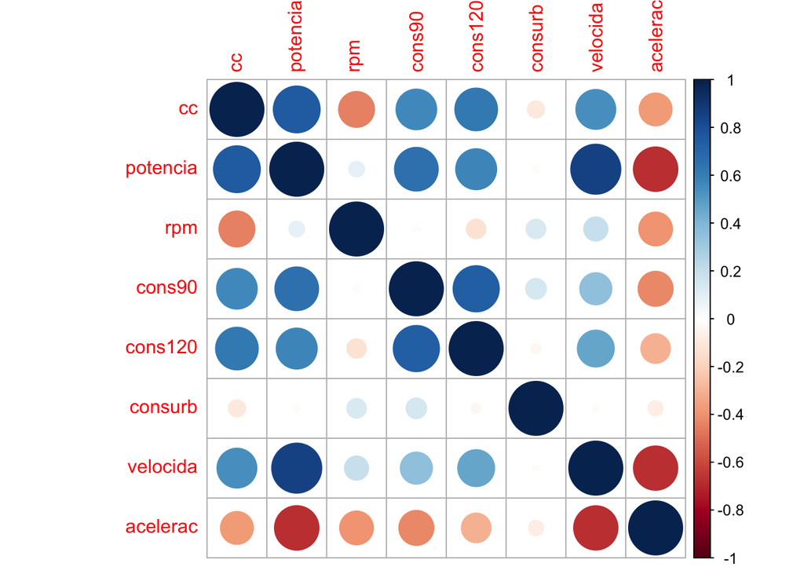

Acorde a la matriz de correlaciones obtenida, se observa que la potencia se encuentra muy asociada a los cilindrada del vehiculo, los consumos a 90 y 120 km/hr y la velocidad máxima. Es un indicador de que puede ser una variable muy a tener en cuenta de cara a la realización de un análisis clúster.

Los consumos a 90 y 120 km/hr presentan correlaciones altas entre sí. El consumo urbano es el que menores correlaciones presenta con el resto de las variables, lo cual puede indicar que posee una mayor capacidad discriminante que el consumo a 90 km/h y el consumo a 120 km/hr; se podría prescindir de estos dos últimos.

Una vez llevado a cabo todo el análisis exploratorio, la marca y el modelo de los vehículos presentan poca importancia a la hora clasificar estos, al igual que el precio en pesetas. Si bien estas variables podrían ser tenidas en cuenta a la hora de realizar grupos de cara a proceder a la venta de los vehículos, no es nuestro objetivo. Por lo que prescindo de ellas.